# Test 2, STAT 245 for yl77

Author

STAT 245 Fall 2023

## Response variable

Fit a regression model using as your response variable: historic numbers of mammals present in Rome (through the year 1950).

## Data Access

You can find your data at: https://sldr.netlify.app/data/roman-mammals.csv

## Context

This dataset was recently analyzed by Leonardo Ancillotto and colleagues in the paper [*No city for wetland species: habitat associations affect mammal persistence in urban areas*](https://royalsocietypublishing.org/doi/10.1098/rspb.2024.0079#d1e1088).

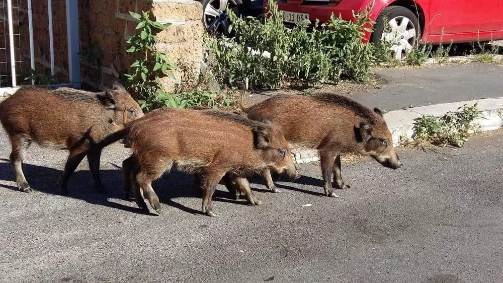

Image from wantedinrome.com

The authors say,

> > The fast rate of replacement of natural areas by expanding cities is a key threat to wildlife worldwide. Many wild species occur in cities, yet little is known on the dynamics of urban wildlife assemblages … species’ ability to spread within urban areas … is likely to shape the fate of species once they occur in a city. Here we use a long-term dataset on mammals occurring in one of the largest and most ancient cities in Europe to assess whether and how spatial spread and association with specific habitats drive the probability of local extinction within cities. Our analysis included mammalian records dating between years 1832 and 2023, and revealed that local extinctions in urban areas are biased towards species associated with wetlands and that were naturally rare within the city. Besides highlighting the role of wetlands within urban areas for conserving wildlife, our work also highlights the importance of long-term biodiversity monitoring in highly dynamic habitats such as cities, as a key asset to better understand wildlife trends and thus foster more sustainable and biodiversity-friendly cities.

Can you confirm any of their findings with your analysis?

Variables in the data set include:

- Variables about the mammal species:
  - its `order`, `genus`, and `species` – the groupings in that list go from larger ones to smaller, that is, each order can include multiple genuses, and each genus multiple species, etc.
- `c1950`, `c1990`, `c2010`, `c2022`: The cumulative number of sightings of the species in Rome, from the start of record-keeping (1832) until the stated date (1950, 1990, 2010, or 2022)
- `extinction` of the species within Rome. The species is considered extinct locally if it has not been seen since 1990 or before.
- `habitat` where the species prefers to live
- `first` sighting of this species in Rome
- `last` sighting of this species in Rome